# Modul 04: Rancangan Petak Terpisah (Split-Plot) & Petak Berjalur (Strip-Plot)

# 1 Mengapa Tidak Semua Percobaan Dua Faktor Bisa Menggunakan Faktorial Biasa?

Pada **Modul 03**, seluruh kombinasi perlakuan $a \times b$ memiliki ukuran petak yang setara dan diacak sekaligus dalam satu tahap sehingga hanya menghasilkan **satu komponen galat percobaan**. Namun dalam praktik penelitian pertanian dan biologi, sering kali terdapat kendala teknis lapangan atau prioritas ketelitian yang mengharuskan pengacakan dilakukan **secara bertahap**, melahirkan rancangan berlapis galat ganda (**Split-Plot**) dan tiga lapis galat (**Strip-Plot / Split-Block**).

| Karakteristik Kunci | Faktorial Biasa (RAK) | Petak Terpisah (*Split-Plot* RAK) | Petak Berjalur (*Strip-Plot* RAK) |
| --- | --- | --- | --- |
| **Kendala Teknis Petak** | Faktor $A$ dan $B$ mudah ditempatkan pada petak kecil setara. | **Faktor $A$ butuh petak besar** (irigasi, traktor, lokasi), Faktor $B$ cukup petak kecil (benih, pupuk). | **Faktor $A$ dan $B$ keduanya butuh jalur memanjang/besar** (traktor bajak $\times$ mesin sebar pupuk). |
| **Prosedur Pengacakan** | 1 tahap terhadap seluruh $ab$ kombinasi sekaligus. | **2 tahap berjenjang**: acak Petak Utama ($A$) dulu, lalu acak Anak Petak ($B$) di dalam tiap $A$. | **2 pengacakan bebas saling tegak lurus**: acak jalur mendatar ($A$) dan acak jalur tegak ($B$) di tiap blok. |
| **Banyak Lapisan Galat** | **1 Galat** ($\text{KTG}$) | **2 Galat**: Galat (a) & Galat (b) | **3 Galat**: Galat (a), Galat (b), & Galat (c) |
| **Urutan Ketelitian Pengujian** | Setara antara $A$, $B$, dan $A \times B$. | **Anak Petak ($B$) & Interaksi ($AB$) lebih teliti** daripada Petak Utama ($A$). | **Interaksi ($AB$) paling teliti**, mengorbankan ketelitian pengaruh utama $A$ dan $B$. |

# 2 Analisis 4.1: Pengacakan Rancangan Split-Plot dan Strip-Plot

## 2.1 Penjelasan Awal (Konsep Dasar)

**Konsep Dasar — Perbedaan Tata Letak Anak Petak vs Petak Berjalur:**

- Pada **Rancangan Petak Terpisah (*Split-Plot*)**: Setiap blok dibagi menjadi $a$ **Petak Utama (*Main Plot / Whole Plot*)** untuk mengacak taraf Faktor $A$. Selanjutnya, masing-masing Petak Utama dibagi lagi menjadi $b$ **Anak Petak (*Subplot*)**, dan taraf Faktor $B$ diacak **secara terpisah/berbeda urutan** di dalam setiap Petak Utama.
- Pada **Rancangan Petak Berjalur (*Strip-Plot / Split-Block*)**: Setiap blok dibagi menjadi $a$ jalur kolom utuh untuk mengacak Faktor $A$, lalu dipotong tegak lurus oleh $b$ jalur baris menerus untuk mengacak Faktor $B$. Akibatnya, urutan taraf Faktor $B$ **sama menerus di sepanjang satu baris melintasi seluruh jalur $A$** di dalam blok yang sama!

## 2.3 Struktur Satuan Percobaan & Derajat Bebas Galat

Untuk $a$ taraf Faktor $A$, $b$ taraf Faktor $B$, dan $r$ ulangan/kelompok (total $N = abr$ petak pengamatan):

- **Split-Plot RAL**: $\text{db}_{\text{Galat (a)}} = a(r - 1)$ dan $\text{db}_{\text{Galat (b)}} = a(b - 1)(r - 1)$.
- **Split-Plot RAK**: $\text{db}_{\text{Galat (a)}} = (a - 1)(r - 1)$ dan $\text{db}_{\text{Galat (b)}} = a(b - 1)(r - 1)$.
- **Strip-Plot RAK**: $\text{db}_{\text{Galat (a)}} = (a - 1)(r - 1)$, $\text{db}_{\text{Galat (b)}} = (b - 1)(r - 1)$, dan $\text{db}_{\text{Galat (c)}} = (a - 1)(b - 1)(r - 1)$.

## 2.4 Kode R Siap Pakai (Step-by-Step)

```r
library(agricolae)

A <- c("A1", "A2", "A3")       # 3 taraf Faktor A
B <- c("B1", "B2", "B3", "B4") # 4 taraf Faktor B

# 1. Pengacakan Split-Plot dalam RAL (CRD): 3 x 3 = 9 Petak Utama, masing-masing 4 Anak Petak
desain_split_ral <- design.split(trt1 = A, trt2 = B, r = 3, design = "crd", seed = 512, serie = 2)
head(desain_split_ral$book, 12)
```

```
#>    plots splots r  A  B
#> 1    101      1 1 A3 B4
#> 2    101      2 1 A3 B3
#> 3    101      3 1 A3 B1
#> 4    101      4 1 A3 B2
#> 5    102      1 1 A1 B2
#> 6    102      2 1 A1 B4
#> 7    102      3 1 A1 B3
#> 8    102      4 1 A1 B1
#> 9    103      1 2 A1 B3
#> 10   103      2 2 A1 B1
#> 11   103      3 2 A1 B2
#> 12   103      4 2 A1 B4
```

```r
# 2. Pengacakan Split-Plot dalam RAK (RCBD): Perhatikan urutan B berbeda di tiap Petak Utama!
desain_split_rak <- design.split(trt1 = A, trt2 = B, r = 3, design = "rcbd", seed = 512, serie = 2)
head(desain_split_rak$book, 12) # Seluruh 12 anak petak pada Blok 1
```

```
#>    plots splots block  A  B
#> 1    101      1     1 A3 B2
#> 2    101      2     1 A3 B1
#> 3    101      3     1 A3 B4
#> 4    101      4     1 A3 B3
#> 5    102      1     1 A1 B3
#> 6    102      2     1 A1 B4
#> 7    102      3     1 A1 B1
#> 8    102      4     1 A1 B2
#> 9    103      1     1 A2 B2
#> 10   103      2     1 A2 B3
#> 11   103      3     1 A2 B4
#> 12   103      4     1 A2 B1
```

```r
# 3. Pengacakan Strip-Plot dalam RAK: Perhatikan urutan B sama persis melintasi jalur A di Blok 1!
desain_strip_rak <- design.strip(trt1 = A, trt2 = B, r = 3, seed = 512, serie = 2)
head(desain_strip_rak$book, 12) # Seluruh 12 petak perpotongan jalur pada Blok 1
```

```
#>    plots block  A  B
#> 1    101     1 A3 B3
#> 2    102     1 A3 B4
#> 3    103     1 A3 B1
#> 4    104     1 A3 B2
#> 5    105     1 A1 B3
#> 6    106     1 A1 B4
#> 7    107     1 A1 B1
#> 8    108     1 A1 B2
#> 9    109     1 A2 B3
#> 10   110     1 A2 B4
#> 11   111     1 A2 B1
#> 12   112     1 A2 B2
```

## 2.5 Cara Membaca Output R & Kesimpulan Kasus

**Bandingkan Perbedaan Mencolok `desain_split_rak$book` vs `desain_strip_rak$book` pada Blok 1:**

1. **Pada Split-Plot RAK (`desain_split_rak$book`)**:
   - Petak Utama `101` mendapat `A3` dengan urutan anak petak **`B2, B1, B4, B3`**.
   - Petak Utama `102` mendapat `A1` dengan urutan anak petak **`B3, B4, B1, B2`** (diacak ulang secara bebas!).
   - Petak Utama `103` mendapat `A2` dengan urutan anak petak **`B2, B3, B4, B1`**.
2. **Pada Strip-Plot RAK (`desain_strip_rak$book`)**:
   - Jalur `A3`, jalur `A1`, dan jalur `A2` pada Blok 1 **ketiganya dipotong oleh urutan jalur tegak $B$ yang persis sama**, yaitu **`B3, B4, B1, B2`**! Perbedaan fisik pengacakan di lapangan inilah yang menyebabkan model matematika Strip-Plot wajib memisahkan Galat (b) tersendiri untuk faktor $B$.

# 3 Analisis 4.2: ANOVA Split-Plot dalam RAL

## 3.1 Penjelasan Awal (Konsep Dasar)

**Konsep Dasar — Dua Satuan Percobaan Berbeda Ukuran pada Split-Plot RAL:**

Pada **Split-Plot dalam RAL**, satuan percobaan untuk Faktor $A$ adalah **Petak Utama** (sebanyak $a \times r$ unit tanpa blok), sehingga keragaman antar-ulangan di dalam taraf $A$ yang sama membentuk **Galat Petak Utama / Galat (a)** yang khusus digunakan sebagai penyebut uji $F$ bagi **Faktor $A$**. Sementara itu, satuan percobaan untuk Faktor $B$ adalah **Anak Petak**, sehingga sisa keragaman di dalam petak utama membentuk **Galat Anak Petak / Galat (b)** sebagai penyebut uji $F$ bagi **Faktor $B$** dan **Interaksi $A \times B$**.

## 3.2 Konteks Kasus & Kapan Menggunakan Analisis Ini

**Studi Kasus — Serapan Debu 10 Jenis Tanaman Pelindung di 2 Lokasi:**

- **Kapan Digunakan?** Gunakan **Split-Plot RAL** apabila faktor Petak Utama ($A$) berupa ruang tumbuh, kolam, atau zona lokasi homogen yang diacak lengkap tanpa blok, lalu di dalam setiap unit petak utama ditanam/ditempatkan seluruh taraf Anak Petak ($B$).
- **Skenario Penelitian**: Penelitian ekologi lanskap mengevaluasi kemampuan **10 jenis tanaman pelindung jalan (`T1` s.d. `T10`, Anak Petak)** dalam menjerap polutan debu daun ($\text{g/m}^2$) pada **2 kawasan Lokasi (`Kampus` vs `Pabrik`, Petak Utama)** dengan **3 titik zona ulangan** per lokasi (total $2 \times 3 = 6$ petak utama, dan $6 \times 10 = 60$ satuan pengamatan anak petak). Dataset tersimpan pada `data/07_debu_splitplot_ral.csv`.

## 3.3 Model Linier, Rumus Uji $F$ Berlapis, & Hipotesis

Model linier aditif untuk Split-Plot dalam RAL adalah:

$$Y_{ijk} = \mu + \alpha_i + \delta_{ik} + \beta_j + (\alpha\beta)_{ij} + \varepsilon_{ijk}; \quad i = 1, \dots, a; \quad j = 1, \dots, b; \quad k = 1, \dots, r$$

di mana:

- $\alpha_i$ : Pengaruh Petak Utama Lokasi ke-$i$, diuji dengan **Galat (a)** $\delta_{ik} \overset{\text{iid}}{\sim} N(0, \sigma_\delta^2)$ berderajat bebas $\text{db}_a = a(r - 1)$:
  $$F_{\text{hitung }(A)} = \frac{\text{KT}_A}{\text{KTG}_a} \sim F_{(\alpha;\; a-1,\; a(r-1))}$$
- $\beta_j$ dan $(\alpha\beta)_{ij}$ : Pengaruh Anak Petak Tanaman ke-$j$ serta Interaksi $\text{Lokasi} \times \text{Tanaman}$, keduanya diuji dengan **Galat (b)** $\varepsilon_{ijk} \overset{\text{iid}}{\sim} N(0, \sigma_\varepsilon^2)$ berderajat bebas $\text{db}_b = a(b - 1)(r - 1)$:
  $$F_{\text{hitung }(B)} = \frac{\text{KT}_B}{\text{KTG}_b}, \qquad F_{\text{hitung }(AB)} = \frac{\text{KT}_{AB}}{\text{KTG}_b}$$

**Tiga Pasang Hipotesis:**

1. **Interaksi $\text{Lokasi} \times \text{Tanaman}$**: $H_0 : (\alpha\beta)_{ij} = 0$ vs $H_1 :$ minimal satu $(\alpha\beta)_{ij} \neq 0$.
2. **Anak Petak (Jenis Tanaman)**: $H_0 : \beta_1 = \dots = \beta_{10} = 0$ vs $H_1 :$ minimal satu $\beta_j \neq 0$.
3. **Petak Utama (Lokasi)**: $H_0 : \alpha_{\text{Kampus}} = \alpha_{\text{Pabrik}}$ vs $H_1 : \alpha_{\text{Kampus}} \neq \alpha_{\text{Pabrik}}$.

## 3.4 Kode R Siap Pakai (Step-by-Step)

```r
# Langkah 1: Membaca data & membentuk identitas unik 6 unit Petak Utama (Lokasi x Ulangan)
df_debu <- read.csv("../data/07_debu_splitplot_ral.csv")
df_debu$Lokasi      <- factor(df_debu$Lokasi, levels = c("Kampus", "Pabrik"))
df_debu$Tanaman     <- factor(df_debu$Tanaman, levels = paste0("T", 1:10))
df_debu$Ulangan     <- factor(df_debu$Ulangan)
df_debu$Petak_Utama <- interaction(df_debu$Lokasi, df_debu$Ulangan)

# Langkah 2: Menjalankan ANOVA Split-Plot RAL dengan suku Error(Petak_Utama)
model_split_ral <- aov(Serapan_Debu ~ Lokasi * Tanaman + Error(Petak_Utama), data = df_debu)
ringkasan_split_ral <- summary(model_split_ral)
print(ringkasan_split_ral)
```

```
#>
#> Error: Petak_Utama
#>           Df Sum Sq Mean Sq F value   Pr(>F)
#> Lokasi     1 1122.5  1122.5    4233 3.34e-07 ***
#> Residuals  4    1.1     0.3
#> ---
#> Signif. codes:  0 '***' 0.001 '**' 0.01 '*' 0.05 '.' 0.1 ' ' 1
#>
#> Error: Within
#>                Df Sum Sq Mean Sq F value Pr(>F)
#> Tanaman         9  754.7   83.85  66.397 <2e-16 ***
#> Lokasi:Tanaman  9   15.8    1.75   1.388   0.23
#> Residuals      36   45.5    1.26
#> ---
#> Signif. codes:  0 '***' 0.001 '**' 0.01 '*' 0.05 '.' 0.1 ' ' 1
```

```r
# Langkah 3: Menghitung Koefisien Keragaman Petak Utama (KKa) dan Anak Petak (KKb)
ktg_a_debu <- ringkasan_split_ral[["Error: Petak_Utama"]][[1]]["Residuals", "Mean Sq"]
ktg_b_debu <- ringkasan_split_ral[["Error: Within"]][[1]]["Residuals", "Mean Sq"]
rata_debu  <- mean(df_debu$Serapan_Debu)

cat(sprintf("Rata-rata = %.2f g/m2 | KTG(a) = %.4f (KKa = %.2f%%) | KTG(b) = %.4f (KKb = %.2f%%)\n",
            rata_debu,
            ktg_a_debu, sqrt(ktg_a_debu) / rata_debu * 100,
            ktg_b_debu, sqrt(ktg_b_debu) / rata_debu * 100))
```

```
#> Rata-rata = 20.17 g/m2 | KTG(a) = 0.2652 (KKa = 2.55%) | KTG(b) = 1.2629 (KKb = 5.57%)
```

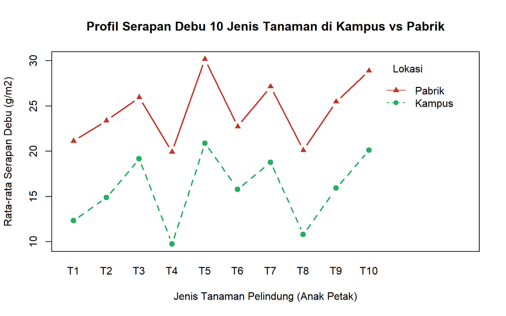

Figure 3.1: Profil rata-rata serapan debu (g/m2) dari 10 jenis tanaman pelindung pada kawasan Kampus dan kawasan Pabrik.

```r
# Langkah 4: Visualisasi profil serapan debu 10 jenis tanaman di kedua lokasi
interaction.plot(
  x.factor     = df_debu$Tanaman,
  trace.factor = df_debu$Lokasi,
  response     = df_debu$Serapan_Debu,
  type = "b", pch = c(19, 17), col = c("#27ae60", "#c0392b"), lwd = 2.2,
  xlab = "Jenis Tanaman Pelindung (Anak Petak)",
  ylab = "Rata-rata Serapan Debu (g/m2)",
  trace.label = "Lokasi",
  main = "Profil Serapan Debu 10 Jenis Tanaman di Kampus vs Pabrik"
)
```

## 3.5 Cara Membaca Output R & Kesimpulan Kasus

**Panduan Membaca Tabel Dua Lapisan (`Error: Petak_Utama` & `Error: Within`):**

1. **Lapisan Atas — `Error: Petak_Utama` (Galat a)**:
   - `Lokasi` memiliki `Df = 1` dan `Residuals` (Galat a) memiliki `Df = 4` ($a(r - 1) = 2(3 - 1) = 4$).
   - Nilai **`F value = 4233`** dengan **`Pr(>F) = 3.34e-07 ***`**: kawasan `Pabrik` memiliki beban paparan dan serapan debu tanaman yang jauh lebih tinggi dibandingkan kawasan `Kampus`.
2. **Lapisan Bawah — `Error: Within` (Galat b)**:
   - `Tanaman` memiliki `Df = 9`, `Lokasi:Tanaman` memiliki `Df = 9`, dan `Residuals` (Galat b) memiliki `Df = 36` ($2 \times 9 \times 2 = 36$).
   - **Interaksi `Lokasi:Tanaman` tidak nyata** (`F = 1.388`, **`Pr(>F) = 0.23 > 0.05`**). Terlihat jelas pada grafik di atas bahwa kurva merah (`Pabrik`) dan kurva hijau (`Kampus`) **bergerak naik-turun secara sejajar**: tanaman yang paling unggul menjerap debu di kawasan Pabrik (`T5`, diikuti `T10` dan `T7`) juga merupakan tanaman terbaik di kawasan Kampus!
   - **Pengaruh Utama `Tanaman` sangat nyata** (`F = 66.397`, **`Pr(>F) < 2e-16 ***`**).

**Kalimat Kesimpulan Siap Kutip:** > *“Berdasarkan analisis ragam Rancangan Petak Terpisah dalam RAL, interaksi antara lokasi penanaman dan jenis tanaman pelindung tidak berpengaruh nyata terhadap serapan debu daun ($F = 1,39$; $p = 0,2300$), namun pengaruh utama lokasi ($F = 4233,0$; $p = 3,34 \times 10^{-7}$; $\text{KK}_a = 2,55\%$) dan pengaruh utama jenis tanaman ($F = 66,40$; $p < 2 \times 10^{-16}$; $\text{KK}_b = 5,57\%$) masing-masing berpengaruh sangat nyata. Tanaman `T5` secara konsisten memiliki kapasitas serapan debu tertinggi baik di lingkungan pabrik maupun kampus.”*

# 4 Analisis 4.3: ANOVA Split-Plot dalam RAK & Uji Lanjut LSMeans

## 4.1 Penjelasan Awal (Konsep Dasar)

**Konsep Dasar — Split-Plot dalam RAK (Rancangan Paling Populer di Agronomi):**

Pada **Split-Plot dalam RAK**, setiap kelompok (blok) dibagi menjadi $a$ Petak Utama, sehingga interaksi formal antara `Kelompok` dan `Faktor A` (`Kelompok:A`) berperan sebagai **Galat Petak Utama / Galat (a)** dengan derajat bebas $(a - 1)(r - 1)$. Sementara itu, **Galat Anak Petak / Galat (b)** memiliki derajat bebas $a(b - 1)(r - 1)$ yang jauh lebih besar, menjadikan pengujian Anak Petak ($B$) dan Interaksi ($A \times B$) memiliki ketelitian lebih tinggi.

## 4.2 Konteks Kasus & Kapan Menggunakan Analisis Ini

**Studi Kasus — Varietas Gandum $\times$ Perlakuan Kimiawi Benih:**

- **Kapan Digunakan?** Gunakan **Split-Plot RAK** ketika percobaan lapangan berblok melibatkan: (1) Faktor $A$ yang membutuhkan petak besar (varietas yang ditanam dengan mesin penebar, sistem irigasi, atau olah tanah), serta (2) Faktor $B$ yang mudah diterapkan pada sub-petak kecil dan ingin diuji secara lebih peka.
- **Skenario Penelitian**: Percobaan klasik pada **4 Varietas Gandum** sebagai **Petak Utama** (`A1_Vicland`, `A2_Branch`, `A3_Clintland`, `A4_Sauk`) dan **4 Perlakuan Fungisida/Kimiawi Benih** sebagai **Anak Petak** (`B1_Kontrol`, `B2_Ceresan`, `B3_Panogen`, `B4_Agrox`) yang diulang dalam **4 Kelompok lahan (`I..IV`)**, mengamati hasil panen gandum (bushels/acre, total $4 \times 4 \times 4 = 64$ anak petak). Dataset tersimpan pada `data/08_gandum_splitplot_rak.csv`.

## 4.3 Model Linier, Rumus Koefisien Keragaman, & Hipotesis

Model linier aditif untuk Split-Plot dalam RAK adalah:

$$Y_{ijk} = \mu + \rho_k + \alpha_i + \delta_{ik} + \beta_j + (\alpha\beta)_{ij} + \varepsilon_{ijk}$$

dengan dua komponen galat dan masing-masing Koefisien Keragamannya:

$$\text{Galat (a): } \text{db}_a = (a - 1)(r - 1), \quad \text{KK}_a = \frac{\sqrt{\text{KTG}_a}}{\bar{Y}_{\cdot\cdot\cdot}} \times 100\%$$

$$\text{Galat (b): } \text{db}_b = a(b - 1)(r - 1), \quad \text{KK}_b = \frac{\sqrt{\text{KTG}_b}}{\bar{Y}_{\cdot\cdot\cdot}} \times 100\%$$

**Pasangan Hipotesis Utama:**

1. **Interaksi $\text{Varietas} \times \text{Perlakuan Benih}$** (diuji terhadap $\text{KTG}_b$): $H_0 : (\alpha\beta)_{ij} = 0$ vs $H_1 :$ minimal satu $(\alpha\beta)_{ij} \neq 0$.
2. **Anak Petak — Perlakuan Benih ($B$)** (diuji terhadap $\text{KTG}_b$): $H_0 : \beta_1 = \dots = \beta_4 = 0$ vs $H_1 :$ minimal satu $\beta_j \neq 0$.
3. **Petak Utama — Varietas ($A$)** (diuji terhadap $\text{KTG}_a$): $H_0 : \alpha_1 = \dots = \alpha_4 = 0$ vs $H_1 :$ minimal satu $\alpha_i \neq 0$.

## 4.4 Kode R Siap Pakai (Step-by-Step)

```r
library(emmeans)
library(multcomp)

# Langkah 1: Membaca data dan mengatur faktor Kelompok, Petak Utama (Varietas_A), & Anak Petak (Perlakuan_B)
df_gandum <- read.csv("../data/08_gandum_splitplot_rak.csv")
df_gandum$Varietas_A  <- factor(df_gandum$Varietas_A)
df_gandum$Perlakuan_B <- factor(df_gandum$Perlakuan_B)
df_gandum$Kelompok    <- factor(df_gandum$Kelompok, levels = c("I", "II", "III", "IV"))

# Langkah 2 (Cara 1): ANOVA Split-Plot RAK menggunakan aov() bawaan R dengan Error(Kelompok:Varietas_A)
model_split_rak <- aov(
  Hasil ~ Kelompok + Varietas_A * Perlakuan_B + Error(Kelompok:Varietas_A),
  data = df_gandum
)
summary(model_split_rak)
```

```
#>
#> Error: Kelompok:Varietas_A
#>            Df Sum Sq Mean Sq F value   Pr(>F)
#> Kelompok    3    186    61.9   12.52  0.00146 **
#> Varietas_A  3   3968  1322.8  267.74 4.09e-09 ***
#> Residuals   9     44     4.9
#> ---
#> Signif. codes:  0 '***' 0.001 '**' 0.01 '*' 0.05 '.' 0.1 ' ' 1
#>
#> Error: Within
#>                        Df Sum Sq Mean Sq F value   Pr(>F)
#> Perlakuan_B             3 165.27   55.09   6.911 0.000858 ***
#> Varietas_A:Perlakuan_B  9  22.06    2.45   0.308 0.967452
#> Residuals              36 286.95    7.97
#> ---
#> Signif. codes:  0 '***' 0.001 '**' 0.01 '*' 0.05 '.' 0.1 ' ' 1
```

```r
# Langkah 3 (Cara 2): Menggunakan agricolae::sp.plot() -> otomatis mencetak Ea, Eb, cv(a), & cv(b)!
with(df_gandum, sp.plot(block = Kelompok, pplot = Varietas_A, splot = Perlakuan_B, Y = Hasil))
```

```
#>
#> ANALYSIS SPLIT PLOT:  Hasil
#> Class level information
#>
#> Varietas_A   :  A1_Vicland A2_Branch A3_Clintland A4_Sauk
#> Perlakuan_B  :  B1_Kontrol B2_Ceresan B3_Panogen B4_Agrox
#> Kelompok     :  I II III IV
#>
#> Number of observations:  64
#>
#> Analysis of Variance Table
#>
#> Response: Hasil
#>                        Df Sum Sq Mean Sq  F value    Pr(>F)
#> Kelompok                3  185.6   61.85   7.7601 0.0004016 ***
#> Varietas_A              3 3968.3 1322.76 267.7422 4.086e-09 ***
#> Ea                      9   44.5    4.94
#> Perlakuan_B             3  165.3   55.09   6.9115 0.0008576 ***
#> Varietas_A:Perlakuan_B  9   22.1    2.45   0.3075 0.9674522
#> Eb                     36  287.0    7.97
#> ---
#> Signif. codes:  0 '***' 0.001 '**' 0.01 '*' 0.05 '.' 0.1 ' ' 1
#>
#> cv(a) = 3.9 %, cv(b) = 4.9 %, Mean = 57.21406
```

```r
# Langkah 4: Uji Lanjut LSMeans (emmeans) sesuai struktur galat Split-Plot
# Karena interaksi A:B tidak nyata (p = 0.9675), fokus utama adalah LSMeans pengaruh utama A dan B:
emm_varietas  <- emmeans(model_split_rak, ~ Varietas_A)
cld(emm_varietas, alpha = 0.05, Letters = letters, adjust = "tukey")
```

```
#>  Varietas_A   emmean    SE df lower.CL upper.CL .group
#>  A1_Vicland     44.7 0.556  9     43.0     46.4  a
#>  A2_Branch      57.7 0.556  9     56.0     59.4   b
#>  A3_Clintland   60.1 0.556  9     58.4     61.9   b
#>  A4_Sauk        66.3 0.556  9     64.6     68.0    c
#>
#> Results are averaged over the levels of: Kelompok, Perlakuan_B
#> Warning: EMMs are biased unless design is perfectly balanced
#> Confidence level used: 0.95
#> Conf-level adjustment: sidak method for 4 estimates
#> P value adjustment: tukey method for comparing a family of 4 estimates
#> significance level used: alpha = 0.05
#> NOTE: If two or more means share the same grouping symbol,
#>       then we cannot show them to be different.
#>       But we also did not show them to be the same.
```

```r
emm_perlakuan <- emmeans(model_split_rak, ~ Perlakuan_B)
pairs(emm_perlakuan, adjust = "tukey")
```

```
#>  contrast                estimate    SE df t.ratio p.value
#>  B1_Kontrol - B2_Ceresan   -2.731 0.998 36  -2.736  0.0453
#>  B1_Kontrol - B3_Panogen   -3.750 0.998 36  -3.757  0.0033
#>  B1_Kontrol - B4_Agrox     -0.225 0.998 36  -0.225  0.9959
#>  B2_Ceresan - B3_Panogen   -1.019 0.998 36  -1.021  0.7386
#>  B2_Ceresan - B4_Agrox      2.506 0.998 36   2.511  0.0751
#>  B3_Panogen - B4_Agrox      3.525 0.998 36   3.531  0.0061
#>
#> Results are averaged over the levels of: Kelompok, Varietas_A
#> P value adjustment: tukey method for comparing a family of 4 estimates
```

```r
cld(emm_perlakuan, alpha = 0.05, Letters = letters, adjust = "tukey")
```

```
#>  Perlakuan_B emmean    SE   df lower.CL upper.CL .group
#>  B1_Kontrol    55.5 0.671 44.8     53.8     57.3  a
#>  B4_Agrox      55.8 0.671 44.8     54.0     57.5  ab
#>  B2_Ceresan    58.3 0.671 44.8     56.5     60.0   bc
#>  B3_Panogen    59.3 0.671 44.8     57.5     61.0    c
#>
#> Results are averaged over the levels of: Kelompok, Varietas_A
#> Warning: EMMs are biased unless design is perfectly balanced
#> Confidence level used: 0.95
#> Conf-level adjustment: sidak method for 4 estimates
#> P value adjustment: tukey method for comparing a family of 4 estimates
#> significance level used: alpha = 0.05
#> NOTE: If two or more means share the same grouping symbol,
#>       then we cannot show them to be different.
#>       But we also did not show them to be the same.
```

```r
# Catatan: Apabila pada kasus lain interaksi A x B nyata, gunakan irisan pengaruh sederhana berikut:
emm_gandum_simple <- emmeans(model_split_rak, ~ Perlakuan_B | Varietas_A)
pairs(emm_gandum_simple, adjust = "tukey")
```

```
#> Varietas_A = A1_Vicland:
#>  contrast                estimate SE df t.ratio p.value
#>  B1_Kontrol - B2_Ceresan   -2.275  2 36  -1.140  0.6679
#>  B1_Kontrol - B3_Panogen   -4.025  2 36  -2.016  0.2010
#>  B1_Kontrol - B4_Agrox     -1.100  2 36  -0.551  0.9457
#>  B2_Ceresan - B3_Panogen   -1.750  2 36  -0.877  0.8169
#>  B2_Ceresan - B4_Agrox      1.175  2 36   0.589  0.9349
#>  B3_Panogen - B4_Agrox      2.925  2 36   1.465  0.4685
#>
#> Varietas_A = A2_Branch:
#>  contrast                estimate SE df t.ratio p.value
#>  B1_Kontrol - B2_Ceresan   -3.450  2 36  -1.728  0.3244
#>  B1_Kontrol - B3_Panogen   -3.550  2 36  -1.778  0.3002
#>  B1_Kontrol - B4_Agrox     -0.525  2 36  -0.263  0.9935
#>  B2_Ceresan - B3_Panogen   -0.100  2 36  -0.050  1.0000
#>  B2_Ceresan - B4_Agrox      2.925  2 36   1.465  0.4685
#>  B3_Panogen - B4_Agrox      3.025  2 36   1.515  0.4392
#>
#> Varietas_A = A3_Clintland:
#>  contrast                estimate SE df t.ratio p.value
#>  B1_Kontrol - B2_Ceresan   -2.825  2 36  -1.415  0.4984
#>  B1_Kontrol - B3_Panogen   -4.725  2 36  -2.367  0.1020
#>  B1_Kontrol - B4_Agrox      1.250  2 36   0.626  0.9230
#>  B2_Ceresan - B3_Panogen   -1.900  2 36  -0.952  0.7773
#>  B2_Ceresan - B4_Agrox      4.075  2 36   2.041  0.1922
#>  B3_Panogen - B4_Agrox      5.975  2 36   2.993  0.0245
#>
#> Varietas_A = A4_Sauk:
#>  contrast                estimate SE df t.ratio p.value
#>  B1_Kontrol - B2_Ceresan   -2.375  2 36  -1.190  0.6372
#>  B1_Kontrol - B3_Panogen   -2.700  2 36  -1.352  0.5366
#>  B1_Kontrol - B4_Agrox     -0.525  2 36  -0.263  0.9935
#>  B2_Ceresan - B3_Panogen   -0.325  2 36  -0.163  0.9984
#>  B2_Ceresan - B4_Agrox      1.850  2 36   0.927  0.7908
#>  B3_Panogen - B4_Agrox      2.175  2 36   1.089  0.6981
#>
#> Results are averaged over the levels of: Kelompok
#> P value adjustment: tukey method for comparing a family of 4 estimates
```

## 4.5 Cara Membaca Output R & Kesimpulan Kasus

**Kalimat Kesimpulan Siap Kutip:** > *“Analisis ragam Rancangan Petak Terpisah dalam RAK menunjukkan tidak terdapat interaksi nyata antara varietas gandum dan perlakuan kimiawi benih ($F = 0,31$; $p = 0,9675$), namun pengaruh utama varietas ($F = 267,74$; $p = 4,09 \times 10^{-9}$; $\text{KK}_a = 3,9\%$) dan perlakuan kimiawi benih ($F = 6,91$; $p = 0,00086$; $\text{KK}_b = 4,9\%$) masing-masing berpengaruh sangat nyata terhadap hasil gandum. Varietas `A4_Sauk` memberikan hasil tertinggi sebesar $66,3\text{ bushels/acre}$, sedangkan perlakuan benih `B3_Panogen` ($59,3\text{ bushels/acre}$) dan `B2_Ceresan` ($58,3\text{ bushels/acre}$) meningkatkan hasil secara nyata dibandingkan kontrol tanpa perlakuan ($55,5\text{ bushels/acre}$).”*

# 5 Analisis 4.4: ANOVA Strip-Plot (*Split-Block*) dalam RAK & Perhitungan $\text{KK}_a, \text{KK}_b, \text{KK}_c$

## 5.1 Penjelasan Awal (Konsep Dasar)

**Konsep Dasar — Tiga Lapisan Galat pada Rancangan Petak Berjalur (*Strip-Plot*):**

Pada **Rancangan Petak Berjalur (*Strip-Plot / Split-Block*)**, Faktor $A$ diaplikasikan dalam jalur kolom menerus dan Faktor $B$ diaplikasikan dalam jalur baris menerus yang memotong tegak lurus di setiap kelompok. Konsekuensinya terdapat **tiga ukuran satuan percobaan dan tiga komponen galat**: 1. **Galat (a)** (`Kelompok:A`) berderajat bebas $(a - 1)(r - 1)$ $\rightarrow$ menguji pengaruh utama **Faktor Mendatar $A$**. 2. **Galat (b)** (`Kelompok:B`) berderajat bebas $(b - 1)(r - 1)$ $\rightarrow$ menguji pengaruh utama **Faktor Tegak $B$**. 3. **Galat (c)** (`Kelompok:A:B` / Sisaan petak perpotongan kecil) berderajat bebas $(a - 1)(b - 1)(r - 1)$ $\rightarrow$ menguji **Interaksi $A \times B$ dengan ketelitian paling tinggi**!

## 5.2 Konteks Kasus & Kapan Menggunakan Analisis Ini

**Studi Kasus — 6 Varietas Padi $\times$ 3 Taraf Pupuk Nitrogen dalam Strip-Plot RAK:**

- **Kapan Digunakan?** Gunakan **Strip-Plot RAK** apabila kedua faktor sama-sama lebih praktis diterapkan dalam jalur panjang menerus (misalnya penanaman jalur varietas mekanis berpotongan tegak lurus dengan jalur pemupukan nitrogen/irigasi) dan peneliti menaruh perhatian utama pada **pengujian interaksi $A \times B$**.
- **Skenario Penelitian**: Percobaan lapangan pada **6 Varietas Padi (`V1` s.d. `V6`)** sebagai jalur mendatar/kolom dan **3 Dosis Pupuk Nitrogen (`N0` = 0, `N60` = 60, `N120` = 120 kg N/ha)** sebagai jalur tegak/baris pada **3 Kelompok sawah (`I, II, III`)**, mengamati **hasil gabah kering (ton/ha)** pada $6 \times 3 \times 3 = 54$ petak perpotongan. Dataset tersimpan pada `data/09_padi_stripplot_rak.csv`.

## 5.3 Model Linier, Rumus Tiga Koefisien Keragaman ($\text{KK}_a, \text{KK}_b, \text{KK}_c$), & Hipotesis

Model linier aditif untuk Rancangan Strip-Plot dalam RAK adalah:

$$Y_{ijk} = \mu + \rho_k + \alpha_i + \delta_{ik} + \beta_j + \gamma_{jk} + (\alpha\beta)_{ij} + \varepsilon_{ijk}$$

Keterangan tiga galat dan rumus Koefisien Keragaman per lapisan galat:

$$\text{KK}_a = \frac{\sqrt{\text{KTG}_a}}{\bar{Y}_{\cdot\cdot\cdot}} \times 100\%, \qquad \text{KK}_b = \frac{\sqrt{\text{KTG}_b}}{\bar{Y}_{\cdot\cdot\cdot}} \times 100\%, \qquad \text{KK}_c = \frac{\sqrt{\text{KTG}_c}}{\bar{Y}_{\cdot\cdot\cdot}} \times 100\%$$

Statistik uji $F$ pada masing-masing lapisan:

$$F_{\text{hitung }(A)} = \frac{\text{KT}_A}{\text{KTG}_a}, \qquad F_{\text{hitung }(B)} = \frac{\text{KT}_B}{\text{KTG}_b}, \qquad F_{\text{hitung }(AB)} = \frac{\text{KT}_{AB}}{\text{KTG}_c}$$

**Tiga Pasang Hipotesis:**

1. **Interaksi $\text{Varietas} \times \text{Nitrogen}$** (diuji dengan $\text{KTG}_c$, $\text{db}_c = 20$): $H_0 : (\alpha\beta)_{ij} = 0$ vs $H_1 :$ minimal satu $(\alpha\beta)_{ij} \neq 0$.
2. **Faktor Jalur Mendatar — Varietas ($A$)** (diuji dengan $\text{KTG}_a$, $\text{db}_a = 10$): $H_0 : \alpha_1 = \dots = \alpha_6 = 0$ vs $H_1 :$ minimal satu $\alpha_i \neq 0$.
3. **Faktor Jalur Tegak — Nitrogen ($B$)** (diuji dengan $\text{KTG}_b$, $\text{db}_b = 4$): $H_0 : \beta_1 = \beta_2 = \beta_3 = 0$ vs $H_1 :$ minimal satu $\beta_j \neq 0$.

## 5.4 Kode R Siap Pakai (Step-by-Step)

```r
# Langkah 1: Membaca data dan mengatur urutan faktor Varietas, Nitrogen, dan Kelompok
df_strip <- read.csv("../data/09_padi_stripplot_rak.csv")
df_strip$Varietas <- factor(df_strip$Varietas, levels = paste0("V", 1:6))
df_strip$Nitrogen <- factor(df_strip$Nitrogen, levels = c("N0", "N60", "N120"))
df_strip$Kelompok <- factor(df_strip$Kelompok, levels = c("I", "II", "III"))

# Langkah 2 (Cara 1): Menggunakan agricolae::strip.plot() -> langsung mencetak Ea, Eb, Ec & cv(a,b,c)
with(df_strip, strip.plot(BLOCK = Kelompok, COL = Varietas, ROW = Nitrogen, Y = Hasil_Gabah))
```

```
#>
#> ANALYSIS STRIP PLOT:  Hasil_Gabah
#> Class level information
#>
#> Varietas     :  V1 V2 V3 V4 V5 V6
#> Nitrogen     :  N0 N60 N120
#> Kelompok     :  I II III
#>
#> Number of observations:  54
#>
#> model Y: Hasil_Gabah ~ Kelompok + Varietas + Ea + Nitrogen + Eb + Nitrogen:Varietas + Ec
#>
#> Analysis of Variance Table
#>
#> Response: Hasil_Gabah
#>                   Df Sum Sq Mean Sq   F value    Pr(>F)
#> Kelompok           2  0.027  0.0133
#> Varietas           5 33.922  6.7843  106.1510 2.479e-08 ***
#> Ea                10  0.639  0.0639
#> Nitrogen           2 30.149 15.0746 1140.3333 3.065e-06 ***
#> Eb                 4  0.053  0.0132
#> Nitrogen:Varietas 10  0.362  0.0362    0.9974    0.4774
#> Ec                20  0.725  0.0362
#> ---
#> Signif. codes:  0 '***' 0.001 '**' 0.01 '*' 0.05 '.' 0.1 ' ' 1
#>
#> cv(a) = 3.9 %, cv(b) = 1.8 %, cv(c) = 3 %, Mean = 6.44
```

```r
# Langkah 3 (Cara 2): Menggunakan aov() bawaan R dengan suku Error(Kelompok:Varietas + Kelompok:Nitrogen)
model_strip <- aov(
  Hasil_Gabah ~ Kelompok + Varietas * Nitrogen +
    Error(Kelompok:Varietas + Kelompok:Nitrogen),
  data = df_strip
)
ringkasan_strip <- summary(model_strip)
print(ringkasan_strip)
```

```
#>
#> Error: Kelompok:Varietas
#>           Df Sum Sq Mean Sq F value   Pr(>F)
#> Kelompok   2   0.03   0.013   0.209    0.815
#> Varietas   5  33.92   6.784 106.151 2.48e-08 ***
#> Residuals 10   0.64   0.064
#> ---
#> Signif. codes:  0 '***' 0.001 '**' 0.01 '*' 0.05 '.' 0.1 ' ' 1
#>
#> Error: Kelompok:Nitrogen
#>           Df Sum Sq Mean Sq F value   Pr(>F)
#> Nitrogen   2 30.149  15.075    1140 3.07e-06 ***
#> Residuals  4  0.053   0.013
#> ---
#> Signif. codes:  0 '***' 0.001 '**' 0.01 '*' 0.05 '.' 0.1 ' ' 1
#>
#> Error: Within
#>                   Df Sum Sq Mean Sq F value Pr(>F)
#> Varietas:Nitrogen 10 0.3615 0.03615   0.997  0.477
#> Residuals         20 0.7249 0.03625
```

```r
# Langkah 4: Perhitungan eksplisit KKa, KKb, dan KKc dari nilai Kuadrat Tengah ketiga galat
ktg_a <- ringkasan_strip[["Error: Kelompok:Varietas"]][[1]]["Residuals", "Mean Sq"]
ktg_b <- ringkasan_strip[["Error: Kelompok:Nitrogen"]][[1]]["Residuals", "Mean Sq"]
ktg_c <- ringkasan_strip[["Error: Within"]][[1]]["Residuals", "Mean Sq"]
rata_umum <- mean(df_strip$Hasil_Gabah)

KKa <- sqrt(ktg_a) / rata_umum * 100
KKb <- sqrt(ktg_b) / rata_umum * 100
KKc <- sqrt(ktg_c) / rata_umum * 100

cat(sprintf("Rata-rata Umum = %.2f ton/ha\n", rata_umum))
```

```
#> Rata-rata Umum = 6.44 ton/ha
```

```r
cat(sprintf("Galat (a) [Varietas] : KTG_a = %.4f | KKa = %.2f%%\n", ktg_a, KKa))
```

```
#> Galat (a) [Varietas] : KTG_a = 0.0639 | KKa = 3.93%
```

```r
cat(sprintf("Galat (b) [Nitrogen] : KTG_b = %.4f | KKb = %.2f%%\n", ktg_b, KKb))
```

```
#> Galat (b) [Nitrogen] : KTG_b = 0.0132 | KKb = 1.79%
```

```r
cat(sprintf("Galat (c) [Interaksi]: KTG_c = %.4f | KKc = %.2f%%\n", ktg_c, KKc))
```

```
#> Galat (c) [Interaksi]: KTG_c = 0.0362 | KKc = 2.96%
```

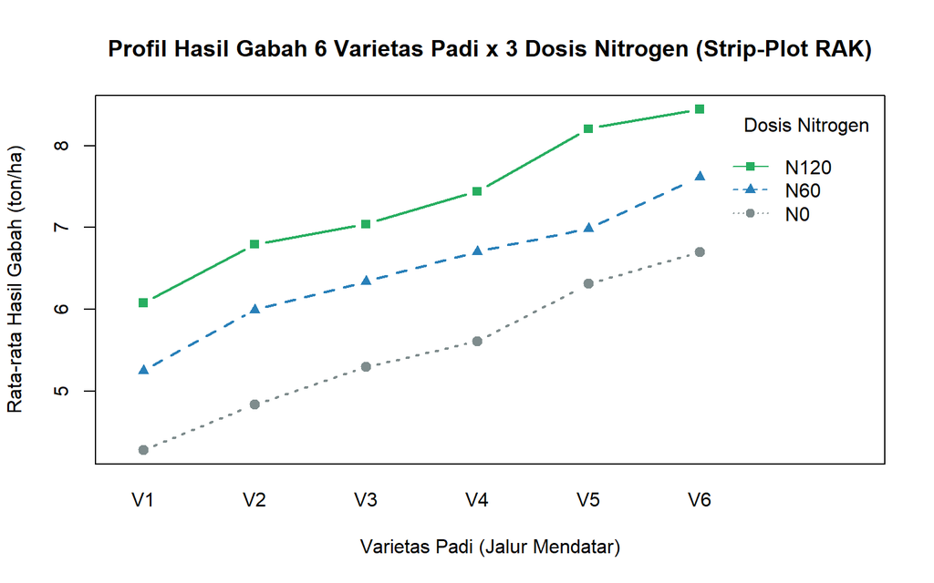

Figure 5.1: Profil hasil gabah kering (ton/ha) 6 varietas padi pada 3 jalur pemupukan Nitrogen dalam Rancangan Strip-Plot RAK.

```r
# Langkah 5: Visualisasi profil respons hasil gabah
interaction.plot(
  x.factor     = df_strip$Varietas,
  trace.factor = df_strip$Nitrogen,
  response     = df_strip$Hasil_Gabah,
  type = "b", pch = c(19, 17, 15), col = c("#7f8c8d", "#2980b9", "#27ae60"), lwd = 2.2,
  xlab = "Varietas Padi (Jalur Mendatar)",
  ylab = "Rata-rata Hasil Gabah (ton/ha)",
  trace.label = "Dosis Nitrogen",
  main = "Profil Hasil Gabah 6 Varietas Padi x 3 Dosis Nitrogen (Strip-Plot RAK)"
)
```

## 5.5 Cara Membaca Output R & Kesimpulan Kasus

**Panduan Membaca Tabel Tiga Galat `strip.plot()` dan `aov()`:**

1. **Verifikasi Derajat Bebas Ketiga Lapisan Galat (`N = 54`, total $\text{db} = 53$)**:
   - `Kelompok = 2`; `Varietas = 5` dengan **`Ea = 10`** ($5 \times 2$); `Nitrogen = 2` dengan **`Eb = 4`** ($2 \times 2$); serta `Nitrogen:Varietas = 10` dengan **`Ec = 20`** ($5 \times 2 \times 2$). Penjumlahan derajat bebas $= 2 + 5 + 10 + 2 + 4 + 10 + 20 = 53$ (tepat!).
2. **Evaluasi Interaksi & Pengaruh Utama**:
   - **Interaksi `Nitrogen:Varietas` (diuji terhadap `Ec = 0.0362`)**: `F value = 0.9974`, **`Pr(>F) = 0.4774` (`> 0.05`, tidak nyata)**. Grafik mengonfirmasi ketiga garis dosis nitrogen sejajar rapi dari `V1` menuju `V6`.
   - **Faktor Mendatar `Varietas` (diuji terhadap `Ea = 0.0639`)**: **`F value = 106.15`**, **`Pr(>F) = 2.48e-08 ***`** (sangat nyata, `V6` tertinggi dan `V1` terendah).
   - **Faktor Tegak `Nitrogen` (diuji terhadap `Eb = 0.0132`)**: **`F value = 1140.33`**, **`Pr(>F) = 3.07e-06 ***`** (sangat nyata, peningkatan nitrogen dari `N0` $\rightarrow$ `N60` $\rightarrow$ `N120` menaikkan hasil gabah secara konsisten pada seluruh varietas).
3. **Tiga Nilai Koefisien Keragaman**: Diperoleh $\text{KK}_a = 3,93\%$ (`3.9%`), $\text{KK}_b = 1,79\%$ (`1.8%`), dan $\text{KK}_c = 2,96\%$ (`3.0%`) terhadap rata-rata umum $6,44\text{ ton/ha}$ — ketiganya di bawah $5\%$, menunjukkan percobaan lapangan dikelola dengan presisi sangat tinggi.

**Kalimat Kesimpulan Siap Kutip:** > *“Berdasarkan analisis ragam Rancangan Petak Berjalur (Strip-Plot) dalam RAK, interaksi antara varietas padi dan pemupukan nitrogen tidak berpengaruh nyata terhadap hasil gabah kering ($F = 1,00$; $p = 0,4774$; $\text{KK}_c = 2,96\%$). Sebaliknya, pengaruh utama varietas padi ($F = 106,15$; $p = 2,48 \times 10^{-8}$; $\text{KK}_a = 3,93\%$) dan pengaruh utama dosis pupuk nitrogen ($F = 1140,33$; $p = 3,07 \times 10^{-6}$; $\text{KK}_b = 1,79\%$) masing-masing berpengaruh sangat nyata, di mana varietas `V6` dan pemupukan `N120` ($120\text{ kg N/ha}$) secara independen memberikan capaian hasil gabah tertinggi.”*